# R4BDS - Breast Cancer Dataset

Authors

Iben Sommerand s203522

Jonas Sennek s203516

Emilie Wenner s193602

Torbjørn Bak Regueira s203555

Vedis Arntzen s203546

## Load data

### Downloading data

```r
raw_dir <- here("data/_raw/")
data_loc <- "https://gdc-hub.s3.us-east-1.amazonaws.com/download/"
download_file(raw_dir,
              data_loc,
              data_file = "TCGA-BRCA.star_fpkm.tsv.gz",
              new_file_name = "gene_expression_fpkm.tsv.gz")
```

```r
download_file(raw_dir,
              data_loc,
              data_file = "TCGA-BRCA.clinical.tsv.gz",
              new_file_name = "phenotypes.tsv.gz")
```

## Loading data

### Phenotype data

```r
phenotypes_subset <- phenotypes |>
  select(sample,
         gender.demographic,
         ajcc_pathologic_stage.diagnoses,
         age_at_diagnosis.diagnoses,
         ethnicity.demographic,
         days_to_death.demographic,
         vital_status.demographic,
         treatment_or_therapy.treatments.diagnoses,
         primary_diagnosis.diagnoses,
         prior_malignancy.diagnoses,
         year_of_diagnosis.diagnoses)
```

### Gene expression data

Sampling 2000 random genes

```r
gene_expression_subset <- gene_expression |>
  sample_n(size = 2000)
```

Pivoting longer

```r
gene_expression_subset_long_format <- gene_expression_subset |>
  pivot_longer(cols = !Ensembl_ID,
               names_to = "sample",
               values_to = "gene_expression")
```

Joining the two datasets

```r
loaded_data <- gene_expression_subset_long_format |>
  inner_join(phenotypes_subset,
             join_by(sample))

loaded_data
```

```
# A tibble: 2,452,000 × 13
   Ensembl_ID   sample gene_expression gender.demographic ajcc_pathologic_stag…¹
   <chr>        <chr>            <dbl> <chr>              <chr>
 1 ENSG0000012… TCGA-…            1.80 female             Stage IIA
 2 ENSG0000012… TCGA-…            1.55 female             Stage IIIA
 3 ENSG0000012… TCGA-…            2.03 female             Stage IIA
 4 ENSG0000012… TCGA-…            1.83 female             Stage IIA
 5 ENSG0000012… TCGA-…            1.16 female             Stage IIB
 6 ENSG0000012… TCGA-…            1.85 male               Stage IV
 7 ENSG0000012… TCGA-…            1.44 female             Stage IV
 8 ENSG0000012… TCGA-…            1.35 female             Stage IIB
 9 ENSG0000012… TCGA-…            1.41 female             Stage IIA
10 ENSG0000012… TCGA-…            1.53 female             Stage IIB
# ℹ 2,451,990 more rows
# ℹ abbreviated name: ¹ajcc_pathologic_stage.diagnoses
# ℹ 8 more variables: age_at_diagnosis.diagnoses <dbl>,
#   ethnicity.demographic <chr>, days_to_death.demographic <dbl>,
#   vital_status.demographic <chr>,
#   treatment_or_therapy.treatments.diagnoses <chr>,
#   primary_diagnosis.diagnoses <chr>, prior_malignancy.diagnoses <chr>, …
```

Save the data as a tsv again

```r
loaded_data |>
  write_tsv(file = here("data/01_dat_load.tsv.gz"),
            na = "NA")
```

## Cleaning the data

### Renaming the columns

```r
clean_data <- loaded_data |>
  rename_with(~ str_replace(., "\\..*", "")) |>
  rename("ensembl_id" = "Ensembl_ID",
         "cancer_stage" = "ajcc_pathologic_stage")
```

### Tidying treatment and therapy

```r
clean_data <- clean_data |>
  mutate(treatment_or_therapy = str_remove_all(treatment_or_therapy,
                                               pattern = "[\\[\\]\\']")) |>
  separate_wider_delim(treatment_or_therapy,
                       delim = ", ",
                       names = c("treatment", "therapy"))
```

### Saving the clean data

```r
write_tsv(x = clean_data,
          file = here("data/02_dat_clean.tsv.gz"), na = "NA")
```

## Augmenting the data

### Age at diagnosis from days to years

```r
clean_data <- clean_data  |>
  mutate(age_at_diagnosis_years = age_at_diagnosis/365.25)
```

### Age grouping

```r
clean_data = clean_data |>
  mutate(age_group = case_when(20 < age_at_diagnosis_years & age_at_diagnosis_years <= 30 ~ "(20,30]",
                               30 < age_at_diagnosis_years & age_at_diagnosis_years <= 40 ~ "(30,40]",
                               40 < age_at_diagnosis_years & age_at_diagnosis_years <= 50 ~ "(40,50]",
                               50 < age_at_diagnosis_years & age_at_diagnosis_years <= 60 ~ "(50,60]",
                               60 < age_at_diagnosis_years & age_at_diagnosis_years <= 70 ~ "(60,70]",
                               70 < age_at_diagnosis_years & age_at_diagnosis_years <= 80 ~ "(70,80]",
                               80 < age_at_diagnosis_years & age_at_diagnosis_years <= 90 ~ "(80,90]"))
```

### Years from diagnosis to death

```r
clean_data <- clean_data  |>
  mutate(years_from_diagnosis_to_death = (days_to_death/365.25))
```

### Age at death in years

```r
clean_data <- clean_data  |>
  mutate(age_at_death_years = age_at_diagnosis_years + years_from_diagnosis_to_death)
```

### Year of death

```r
clean_data <- clean_data  |>
  mutate(year_of_death = year_of_diagnosis+years_from_diagnosis_to_death)
```

### Write to tsv

```r
clean_data |> write_tsv(file = here("data/03_dat_aug.tsv.gz"), na = "NA")
```

## Describing the data

### Creating a table1 to summarize data

```r
data |>
  filter(!is.na(vital_status)) |>
  table1(x = formula(~ gender + ethnicity + age_group + cancer_stage | vital_status),
         data = _)
```

|  | Alive (N=2050000) | Dead (N=400000) | Overall (N=2450000) |
| --- | --- | --- | --- |
| gender |  |  |  |
| female | 2026000 (98.8%) | 398000 (99.5%) | 2424000 (98.9%) |
| male | 24000 (1.2%) | 2000 (0.5%) | 26000 (1.1%) |
| ethnicity |  |  |  |
| hispanic or latino | 76000 (3.7%) | 2000 (0.5%) | 78000 (3.2%) |
| not hispanic or latino | 1596000 (77.9%) | 376000 (94.0%) | 1972000 (80.5%) |
| not reported | 378000 (18.4%) | 22000 (5.5%) | 400000 (16.3%) |
| age_group |  |  |  |
| (20,30] | 16000 (0.8%) | 2000 (0.5%) | 18000 (0.7%) |
| (30,40] | 116000 (5.7%) | 34000 (8.5%) | 150000 (6.1%) |
| (40,50] | 424000 (20.7%) | 72000 (18.0%) | 496000 (20.2%) |
| (50,60] | 550000 (26.8%) | 72000 (18.0%) | 622000 (25.4%) |
| (60,70] | 534000 (26.0%) | 94000 (23.5%) | 628000 (25.6%) |
| (70,80] | 270000 (13.2%) | 74000 (18.5%) | 344000 (14.0%) |
| (80,90] | 108000 (5.3%) | 52000 (13.0%) | 160000 (6.5%) |
| Missing | 32000 (1.6%) | 0 (0%) | 32000 (1.3%) |
| cancer_stage |  |  |  |
| Stage I | 170000 (8.3%) | 42000 (10.5%) | 212000 (8.7%) |
| Stage IA | 176000 (8.6%) | 8000 (2.0%) | 184000 (7.5%) |
| Stage IB | 12000 (0.6%) | 0 (0%) | 12000 (0.5%) |
| Stage II | 12000 (0.6%) | 0 (0%) | 12000 (0.5%) |
| Stage IIA | 704000 (34.3%) | 94000 (23.5%) | 798000 (32.6%) |
| Stage IIB | 492000 (24.0%) | 92000 (23.0%) | 584000 (23.8%) |
| Stage IIIA | 284000 (13.9%) | 62000 (15.5%) | 346000 (14.1%) |
| Stage IIIB | 40000 (2.0%) | 22000 (5.5%) | 62000 (2.5%) |
| Stage IIIC | 124000 (6.0%) | 18000 (4.5%) | 142000 (5.8%) |
| Stage IV | 10000 (0.5%) | 34000 (8.5%) | 44000 (1.8%) |
| Stage X | 12000 (0.6%) | 14000 (3.5%) | 26000 (1.1%) |
| Stage III | 0 (0%) | 4000 (1.0%) | 4000 (0.2%) |
| Missing | 14000 (0.7%) | 10000 (2.5%) | 24000 (1.0%) |

### The below graph shows the amount of people for stage of cancer

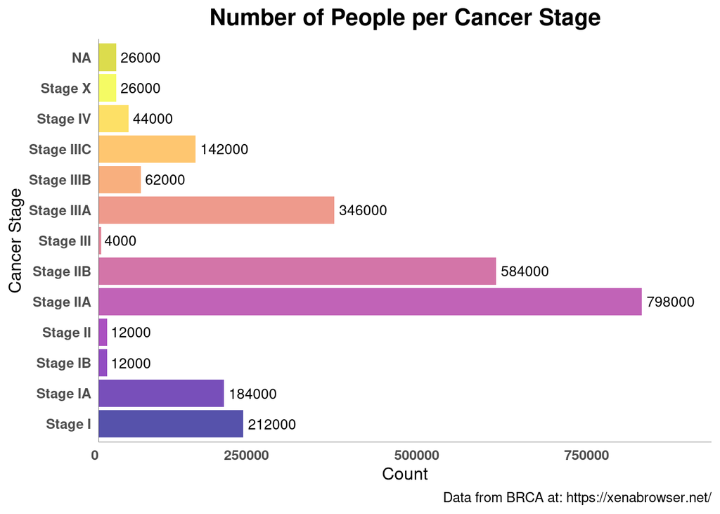

```r
people_per_stage <- ggplot(data,
       aes(y = cancer_stage,
           fill = cancer_stage)) +
  geom_bar(stat = "count", alpha=0.7) +
  geom_text(stat = "count", aes(label = after_stat(count)),
            hjust = -0.1, size = 3.5, color = "black") +
  scale_x_continuous(limits = c(0, 900000),
                     expand = c(0, 0)) +
  scale_fill_viridis_d(option = "plasma",
                       na.value = "yellow3") +
  labs(
    title = "Number of People per Cancer Stage",
    caption = "Data from BRCA at: https://xenabrowser.net/",
    x = "Count",
    y = "Cancer Stage"
  ) +
  theme_minimal(base_size = 12) +
  theme(
    plot.title = element_text(hjust = 0.5, size = 16, face = "bold"),
    axis.text.x = element_text(hjust = 1, vjust = 1, face = "bold"),
    axis.text.y = element_text(face = "bold"),
    panel.grid = element_blank(),
    axis.line = element_line(color = "black", size = 0.1),
    legend.position = "none"
    )


people_per_stage
```

Here, it becomes clear that the most prominent cancer stage represented in the data is stage IIA, while Stage II and Stage IB are more sparse.

### Illustrating the sexes and ethnicities of the people tested (removed NA values)

```r
sex_and_ethnicity_data <- data |>
  filter(!is.na(gender) & !is.na(ethnicity))
```

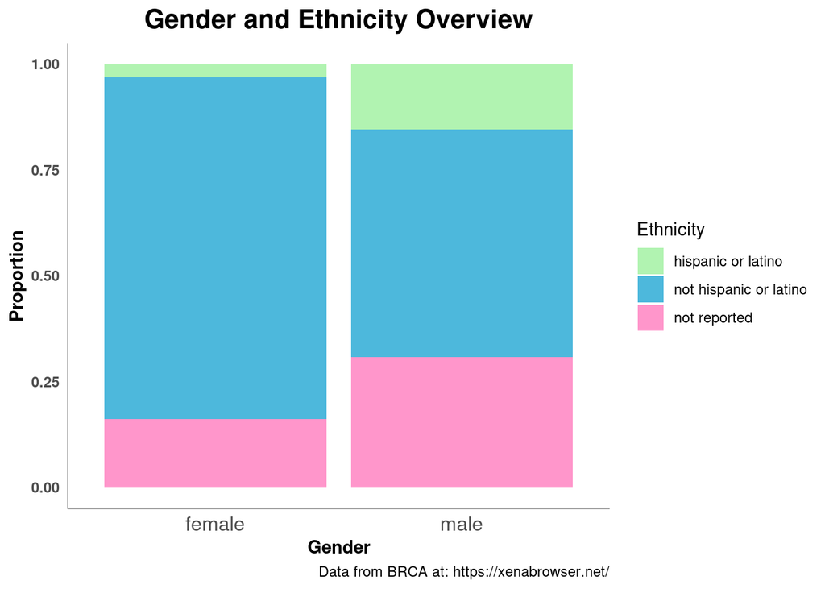

```r
gender_ethnicity_overview <- ggplot(sex_and_ethnicity_data,
       aes(x = gender,
           fill = ethnicity))+
  geom_bar(position = "fill", alpha = 0.7) +
  scale_fill_manual(values = c("hispanic or latino" = "lightgreen",
                               "not hispanic or latino" = "deepskyblue3",
                               "not reported" = "hotpink")) +
  labs(
    title = "Gender and Ethnicity Overview",
    x = "Gender",
    y = "Proportion",
    caption = "Data from BRCA at: https://xenabrowser.net/",
    fill = "Ethnicity"
  ) +
  theme_minimal()+
  theme(
  plot.title = element_text(hjust = 0.5, size = 16, face = "bold"),
  axis.title = element_text(face="bold"),
  axis.text.x = element_text(size = 12),
  axis.text.y = element_text(face = "bold"),
  panel.grid = element_blank(),
  axis.line = element_line(color = "black", linewidth = 0.1),
  legend.position = "right"
  )

gender_ethnicity_overview
```

It is hereby noticiable that the majority of the ethnicities represented are categorised as “not hispanic or latino”. This is a lack within in the dataset, which does not specify specific ethnicities, but rather categorizes patient as either latino or not latino.

It should be noted that the y-axis here is proportion, and that the ethnicities are represented as a fraction of the data within each gender. This is important so as to avoid any confusion on how well each gender is represented in the data (as seen in the table1 above, men only make up 1.1% of the dataset).

### Looking at whether therapy and treatment have any effect on days to death

```r
treatment_graph_data <- data |>
    filter(!is.na(treatment), !is.na(days_to_death), treatment != "not reported")

therapy_graph_data  <- data |>
    filter(!is.na(therapy), !is.na(days_to_death), therapy != "not reported")
```

```r
treatment_effects <- ggplot(treatment_graph_data,
             aes(x = treatment,
                 y = days_to_death,
                 fill = treatment)) +
  geom_boxplot(alpha=0.7) +
  scale_fill_manual(values = c("yes" = "darkolivegreen",
                             "no" = "coral3")) +
  labs(
    title = "Days to Death by Treatment",
    x = "Treatment",
    y = "Days to Death",
    caption = "Data from BRCA at: https://xenabrowser.net/",
    fill = NULL
  ) +
  theme_minimal(base_size = 10) +
  theme(
    plot.title = element_text(hjust = 0.5, size = 14, face = "bold"),
    axis.text.x = element_text(size=11),
    strip.text = element_text(size = 12, face = "bold"),
    legend.position = "none"
  )
```

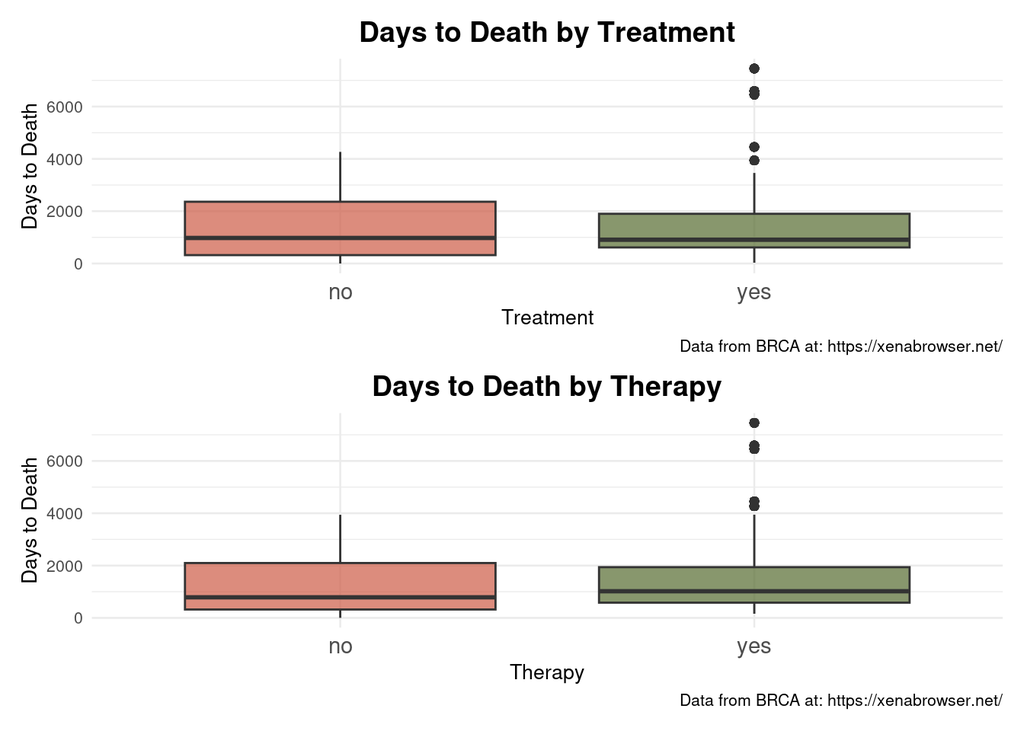

```r
therapy_effects <- ggplot(therapy_graph_data,
             aes(x = therapy,
                 y = days_to_death,
                 fill = therapy)) +
  geom_boxplot(alpha=0.7) +
  scale_fill_manual(values = c("yes" = "darkolivegreen",
                             "no" = "coral3")) +
  labs(
    title = "Days to Death by Therapy",
    x = "Therapy",
    y = "Days to Death",
    caption = "Data from BRCA at: https://xenabrowser.net/",
    fill = NULL
  ) +
  theme_minimal(base_size = 10) +
  theme(
    plot.title = element_text(hjust = 0.5, size = 14, face = "bold"),
    axis.text.x = element_text(size=11),
    strip.text = element_text(size = 12, face = "bold"),
    legend.position = "none"
  )


combined_plot <- treatment_effects / therapy_effects


combined_plot
```

This graph shows slight differences, but it is not very clear whether there is a real effect of each treatment. Therefore, it would be beneficial to represent this data in a different way, as seen below. Here, we can create a new column for the treatment combinations, and stratify this data by vitality status.

### Looking at whether therapy, treatment, both or neither have any effect on whether the patient lives or not

```r
combined_data <- data |>
  mutate(
    combined_category = case_when(
      therapy == "yes" & treatment == "yes" ~ "Both",
      therapy == "no" & treatment == "yes" ~ "Treatment Only",
      therapy == "yes" & treatment == "no" ~ "Therapy Only",
      therapy == "no" & treatment == "no" ~ "Neither",
      TRUE ~ NA_character_
    )
  ) |>
  filter(!is.na(combined_category), !is.na(vital_status))
```

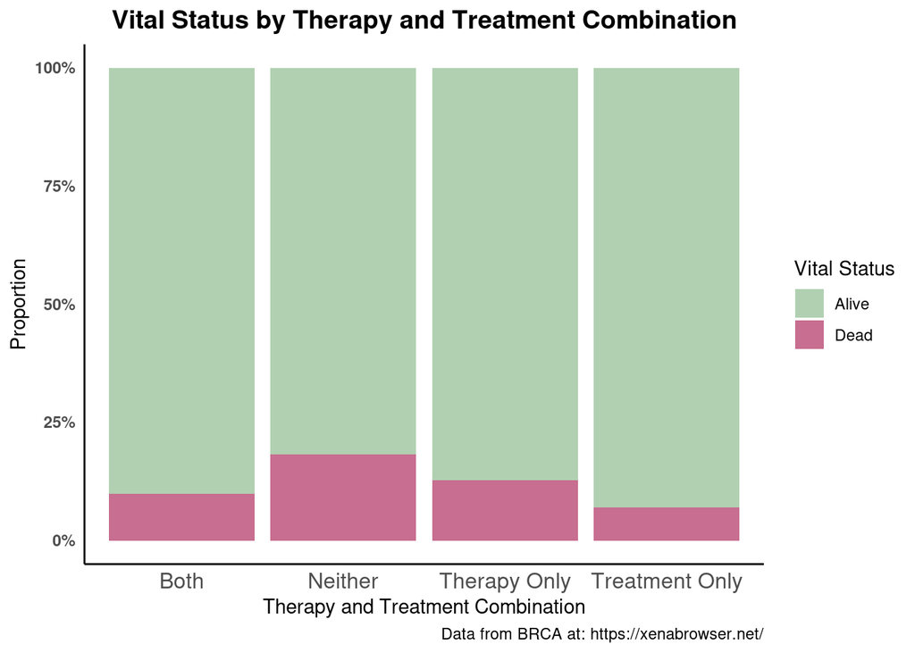

```r
treatment_vs_therapy <- ggplot(combined_data,
       aes(x = combined_category,
           fill = vital_status)) +
  geom_bar(position = "fill", alpha=0.7) +
  scale_fill_manual(values = c("Alive" = "darkseagreen", "Dead" = "maroon")) +
    scale_y_continuous(labels = scales::percent) +
  labs(
    title = "Vital Status by Therapy and Treatment Combination",
    x = "Therapy and Treatment Combination",
    y = "Proportion",
    caption = "Data from BRCA at: https://xenabrowser.net/",
    fill = "Vital Status"
  ) +
  theme_minimal() +
  theme(
    axis.text.x = element_text(size=12),
    axis.text.y = element_text(face = "bold"),
    plot.title = element_text(hjust = 0.5, size = 14, face = "bold"),
    strip.text = element_text(size = 12, face = "bold"),
    panel.grid = element_blank(),
    axis.line = element_line(color = "black")
  )


treatment_vs_therapy
```

### Graph showing whether a given age is more likely to survive

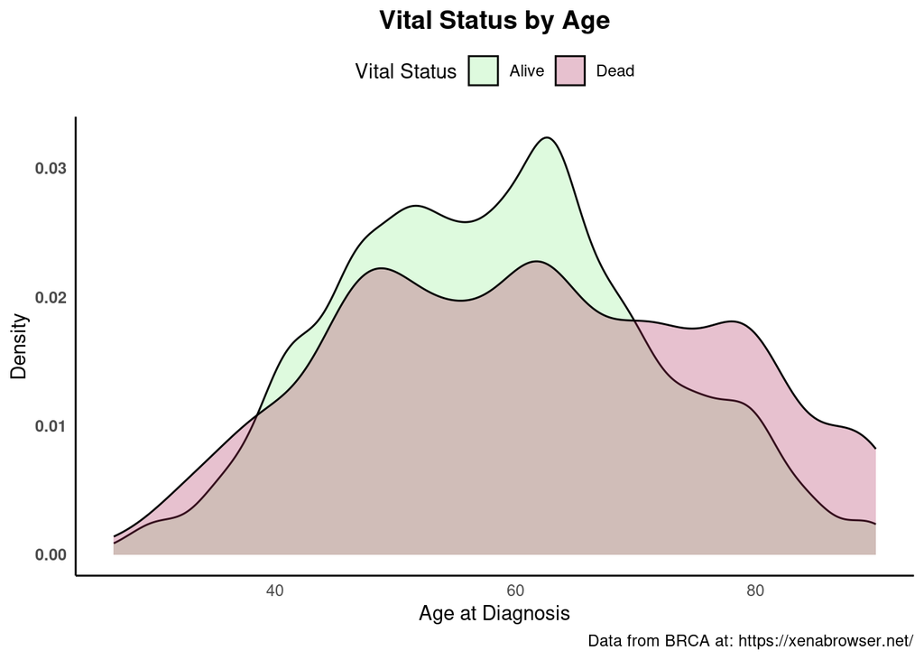

```r
survival_by_age <- ggplot(data |>
         filter(!is.na(age_at_diagnosis_years)),
         aes(x = age_at_diagnosis_years,
             fill = vital_status)) +
  geom_density(alpha = 0.3,
               position = "identity",
               adjust = 3) +  # adjust the smoothness
  scale_fill_manual(values = c("Alive" = "lightgreen",
                               "Dead" = "maroon")) +
  labs(
    title = "Vital Status by Age",
    x = "Age at Diagnosis",
    y = "Density",
    caption = "Data from BRCA at: https://xenabrowser.net/",
    fill = "Vital Status"
  ) +
  theme_minimal()+
  theme(
  axis.text.y = element_text(face = "bold"),
  plot.title = element_text(hjust = 0.5, size = 14, face = "bold"),
  strip.text = element_text(size = 12, face = "bold"),
  legend.position = "top",
  panel.grid = element_blank(),
  axis.line = element_line(color = "black")
)


survival_by_age
```

### Percentage of dead and alive people of each gender for each ethnicity.

```r
data_summary <- data |>
  filter(!is.na(gender) & !is.na(vital_status) & !is.na(ethnicity) & ethnicity != "not reported") |>
  group_by(gender, ethnicity, vital_status) |>
  summarise(count = n(), .groups = "drop") |>
  group_by(ethnicity, gender) |>

  mutate(total_count = sum(count)) |>

  ungroup() |>

  mutate(percentage = (count / total_count) * 100) |>
  mutate(percentage = ifelse(gender == "female",
                               percentage,
                               -1*percentage)) |>

  bind_rows(tibble(gender = "male", ethnicity = "hispanic or latino", vital_status = "Dead", percentage = 0))
```

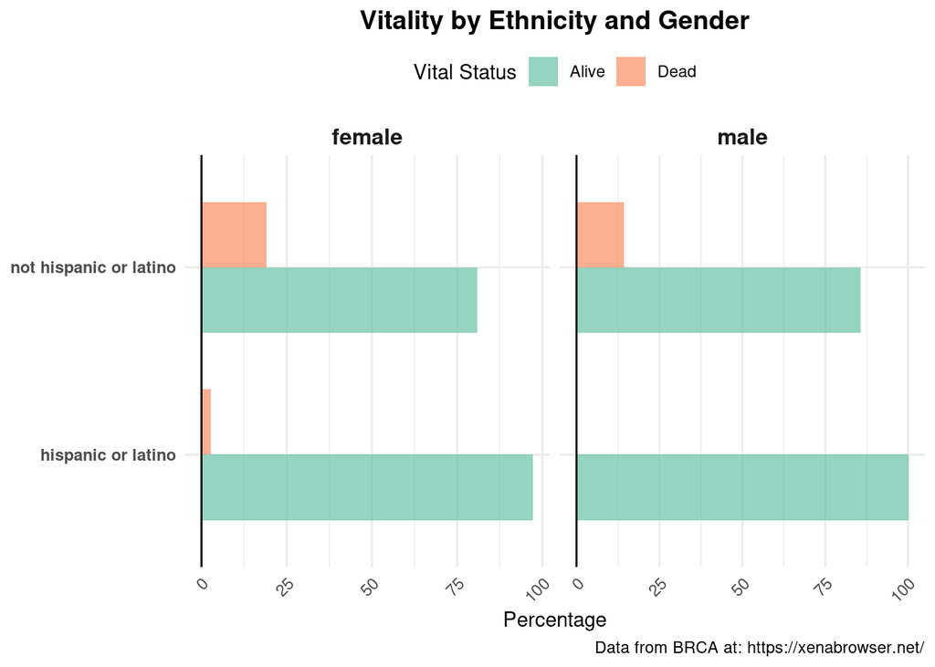

```r
gender_ethnicity_vitality <- ggplot(data_summary,
       aes(x = ethnicity,
           y = ifelse(gender == "female", percentage, -percentage),
           fill = vital_status)) +
  geom_bar(stat = "identity", position = "dodge", width = 0.7, alpha=0.7) +
  geom_hline(yintercept = 0, color = "black", linewidth = 0.5) +
  coord_flip() +
  scale_fill_manual(values = c("Alive" = "#66c2a5", "Dead" = "#fc8d62")) +
  facet_wrap(~ gender, scales = "free_x", ncol = 2) +
  labs(
    title = "Vitality by Ethnicity and Gender",
    x = NULL,
    y = "Percentage",
    caption = "Data from BRCA at: https://xenabrowser.net/",
    fill = "Vital Status"
  ) +
  theme_minimal() +
  theme(
    axis.text.x = element_text(angle = 45, hjust = 1),
    axis.text.y = element_text(face = "bold"),
    plot.title = element_text(hjust = 0.5, size = 14, face = "bold"),
    strip.text = element_text(size = 12, face = "bold"),
    legend.position = "top"
  )


gender_ethnicity_vitality
```

Again, it should be noted that this data is shown as a percentage, as a very small subset of the data represents men. However, it can still be noted that a greater percentage of non-hispanic people in the study have died, as opposed to latino patients. This is true for both genders, and may explain why the researchers have divided the patient ethnicities into these two groups.

### Investigating whether prior malignancy affects days to death

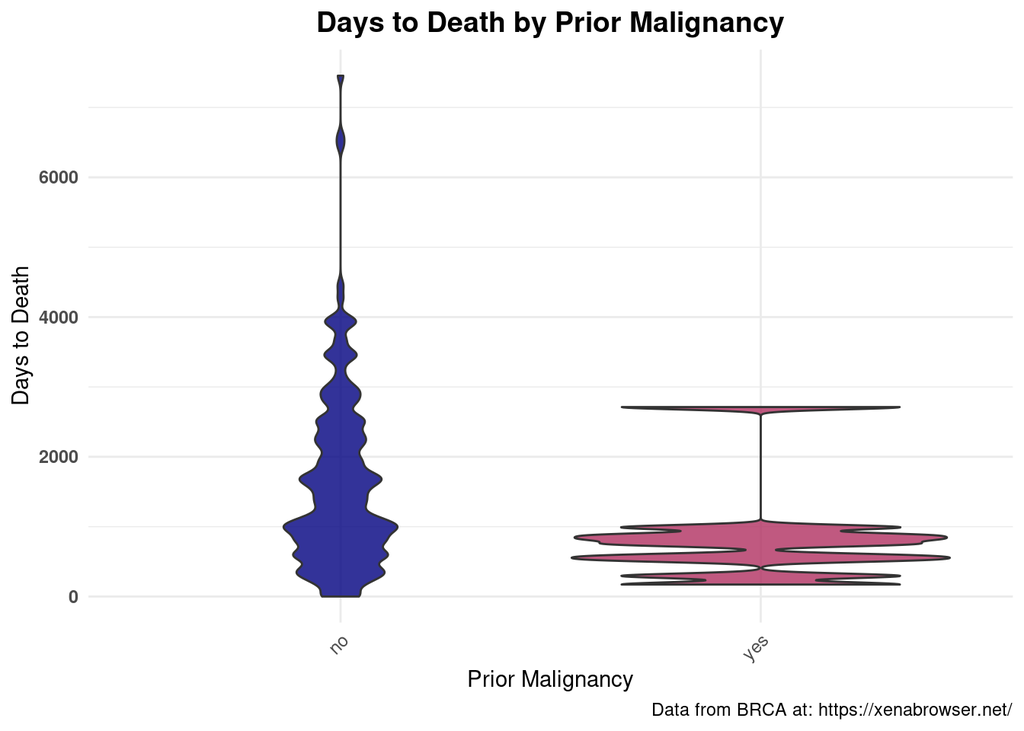

```r
days_to_death_prior_malignancy <- ggplot(data |>
         filter(!is.na(prior_malignancy) & !is.na(days_to_death)),
       aes(x = prior_malignancy, y = days_to_death, fill = prior_malignancy)) +
  geom_violin(alpha=0.8) +  # Use violin plot
  scale_fill_manual(values = c("no" = "navyblue", "yes" = "maroon")) +
  labs(
    title = "Days to Death by Prior Malignancy",
    caption = "Data from BRCA at: https://xenabrowser.net/",
    x = "Prior Malignancy",
    y = "Days to Death"
  ) +
  theme_minimal() +
  theme(
  axis.text.x = element_text(angle = 45, hjust = 1),
  axis.text.y = element_text(face = "bold"),
  plot.title = element_text(hjust = 0.5, size = 14, face = "bold"),
  strip.text = element_text(size = 12, face = "bold"),
  legend.position = "none"
)

# display
days_to_death_prior_malignancy
```

Here, it is clear that prior malignancy has an effect on the survival of each patient. Again, this data follows logic and shows that the presence of a prior malignancy decreases the number of days each patient has left to live.

### The below graphs shows the vitality for each type of cancer.

First the category titles are too long to be legible, so we rename them to be shorter (this does affect the understanding a little, but is worth it to be allow the viewer to read the text):

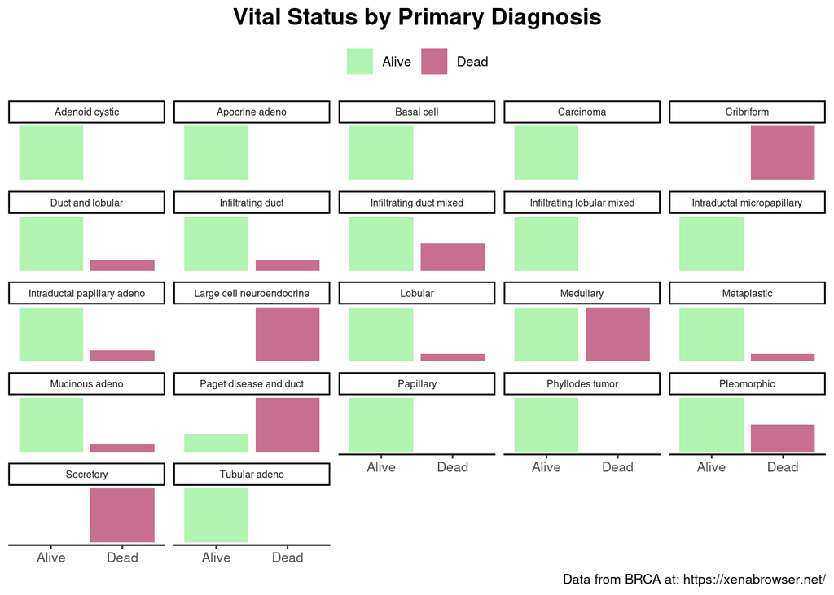

```r
cancer_type_vitality_v1 <-ggplot(data_primary_diagnosis_graph,
       aes(x = vital_status, fill = vital_status)) +
  geom_bar(alpha=0.7) +
  scale_fill_manual(values = c("Alive" = "lightgreen", "Dead" = "maroon")) +
  facet_wrap(~ primary_diagnosis_short, scales = "free_y") +
  scale_y_continuous(breaks = NULL) +
  labs(title = "Vital Status by Primary Diagnosis",
       x = NULL,
       y = NULL,
       caption = "Data from BRCA at: https://xenabrowser.net/",
       fill = NULL) +
  theme_classic(base_size = 10) +
  theme(
    strip.text = element_text(size = 6, angle = 0, hjust = 0.5, vjust = 0.5),
    plot.title = element_text(hjust = 0.5, size = 14, face = "bold"),
    legend.position = "top"
  )

cancer_type_vitality_v1
```

This plot shows the vitality data for each type of cancer, but is quite overwhelming to look at. Therefore, we create another graph which represents the same data as a stacked bar graph with proportions.

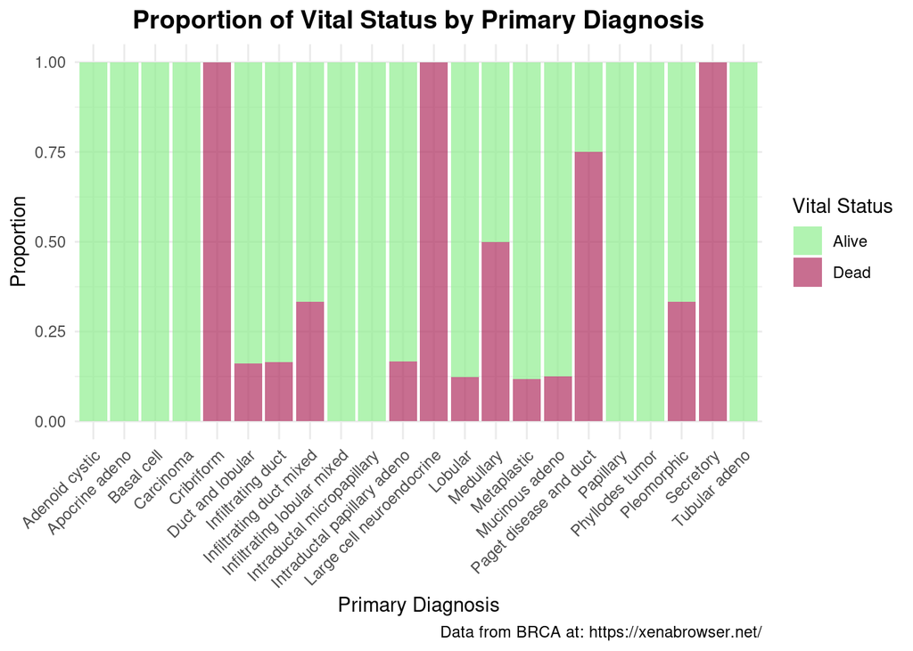

```r
cancer_type_vitality_v2 <- ggplot(data_primary_diagnosis_graph,
       aes(x = primary_diagnosis_short,
           fill = vital_status)) +
  geom_bar(position = "fill", alpha=0.7) +
  scale_fill_manual(values = c("Alive" = "lightgreen", "Dead" = "maroon")) +
  labs(title = "Proportion of Vital Status by Primary Diagnosis",
       x = "Primary Diagnosis",
       y = "Proportion",
       caption = "Data from BRCA at: https://xenabrowser.net/",
       fill = "Vital Status")+
  theme_minimal() +
  theme(
    axis.text.x = element_text(angle = 45, hjust = 1),
    plot.title = element_text(hjust = 0.5, size = 14, face = "bold"),
    )

cancer_type_vitality_v2
```

This graph is easier to interpret, and shows that some primary diagnoses (e.g. secretory breast carcinoma) have a 100% mortality rate, while others (e.g. adenoid cystic carcinoma) have much better changes of survival.

## Analysing impact of cancer stage

### Add factors to relevant colums

```r
data <- data |>
  mutate(vital_status = factor(vital_status,
                               levels = c("Dead",
                                          "Alive")),
         cancer_stage = factor(cancer_stage,
                               levels = c("Stage I",
                                          "Stage IA",
                                          "Stage IB",
                                          "Stage II",
                                          "Stage IIA",
                                          "Stage IIB",
                                          "Stage IIIA",
                                          "Stage IIIB",
                                          "Stage IIIC",
                                          "Stage IV"))
         )
```

## Survival time by cancer stage

Let’s take a look at survival times for the different cancer stages.

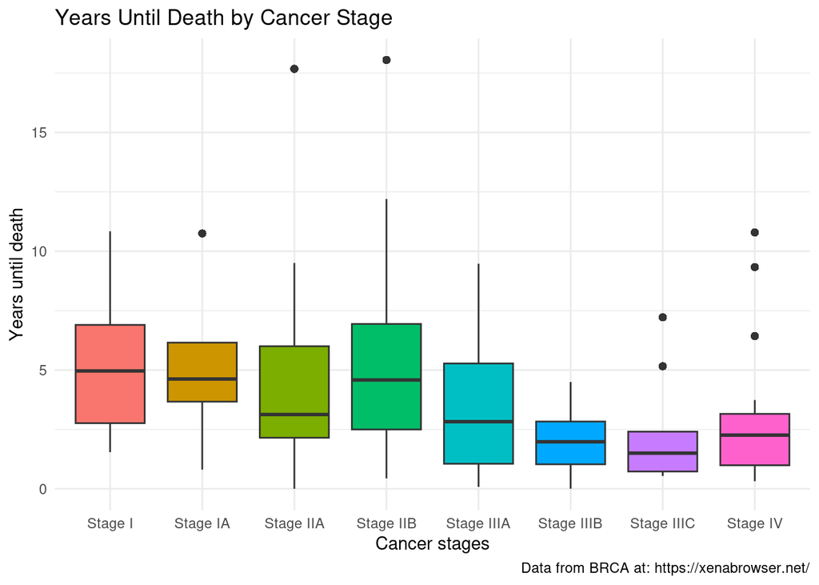

```r
data |>
  filter(cancer_stage != "Stage IB" &
           cancer_stage != "Stage II" &
           vital_status == "Dead") |>
  ggplot(mapping = aes(x = cancer_stage,
                       y = years_from_diagnosis_to_death,
                       fill = cancer_stage)
         ) +
  geom_boxplot() +
  labs(x = "Cancer stages",
       y = "Years until death",
       caption = "Data from BRCA at: https://xenabrowser.net/",
       title = "Years Until Death by Cancer Stage") +
  theme_minimal() +
  theme(legend.position = 'none')
```

In general it seems the worse the cancer stage of a patient is when diagnosed, the shorter until the patient dies. There is however a weird insight, namely that patients diagnosed with stage IIB cancer lives longer than patients with stage IIA cancer, which is counter intuitive. This could be an artifact of the fact that this study is right-censored.

Let’s take a look at the amount of dead and alive patients across cancer stage

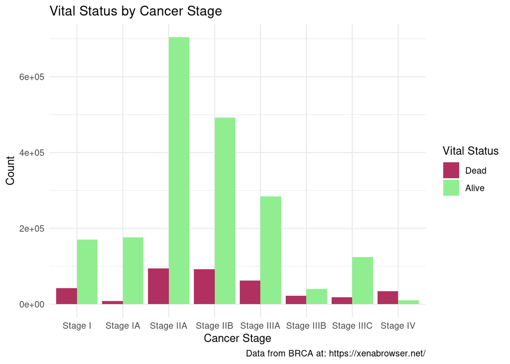

```r
data |>
  drop_na(cancer_stage) |>
  filter(cancer_stage != "Stage IB" & cancer_stage != "Stage II") |>
  ggplot(aes(x = cancer_stage, fill = vital_status)) +
  geom_bar(position = "dodge") +
  scale_fill_manual(values = c("Alive" = "lightgreen", "Dead" = "maroon")) +
  labs(
    title = "Vital Status by Cancer Stage",
    x = "Cancer Stage",
    y = "Count",
    caption = "Data from BRCA at: https://xenabrowser.net/",
    fill = "Vital Status"
  ) +
  theme_minimal()
```

We can see that most patients are diagnosed in stage IIA and stage IIB, which is also the stages with the most patients surviving.

## Performing a PCA

Pivoting the dataset into a wide format:

```r
data_pivot <- data |>
  pivot_wider(
    names_from = ensembl_id,
    values_from = gene_expression
  )
```

Selecting the gene expression data from all the genes, and removing the genes which have a gene expression og 0 for all patients. Then the principal component analysis is performed using prcomp:

```r
pca_fit <- data_pivot |>
  select(starts_with("ENSG")) |>
  select(where(~ any(. != 0))) |>
  prcomp(scale = TRUE)
```

The eigenvalues are extracted in a tidy format, and used to make plot axes labels for the PCA plot, which consists of the principal component and the proportion of variance explained for this PC:

```r
pca_plot_axes_labels <- pca_fit |>
  tidy("eigenvalues") |>
  mutate(lbl = str_c("PC", PC, ", VE = ", round(percent*100,2), "%")) |>
  pull("lbl")
```

The PCA plot is produced, stratified on the cancer stage:

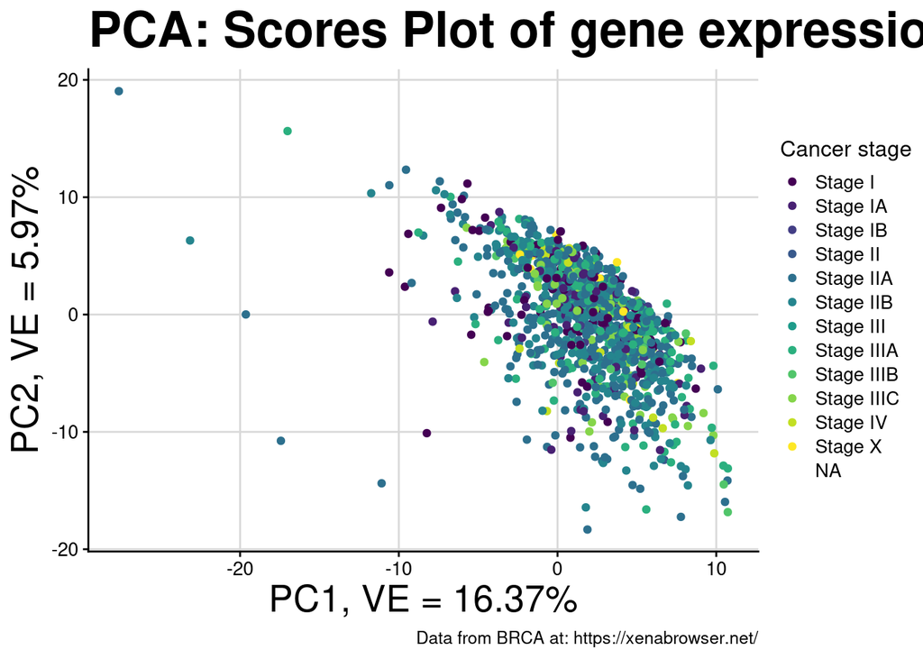

```r
pca_plot <- pca_fit |>
  augment(data_pivot) |>
  filter(abs(.fittedPC1) < 50 & abs(.fittedPC2) < 50) |>
  ggplot(aes(.fittedPC1, .fittedPC2, color = cancer_stage)) +
  geom_point(size = 1.5) +
  theme_half_open(12) +
  theme(plot.title = element_text(size=27),
        axis.title.x = element_text(size = 20),
        axis.title.y = element_text(size = 20)) +
  background_grid() +
  labs(title = "PCA: Scores Plot of gene expression",
    x = pluck(pca_plot_axes_labels, 1),
    y = pluck(pca_plot_axes_labels, 2),
    color = "Cancer stage",
    caption = "Data from BRCA at: https://xenabrowser.net/") +
  scale_colour_viridis_d()

pca_plot
```

Because there is only one big cluster in the PCA we cannot say anything about if the patients are grouped together by the gene expression of certain genes.

## Scree plot

Creating a scree plot of the principal components to see how much information is explained by each of the PCs:

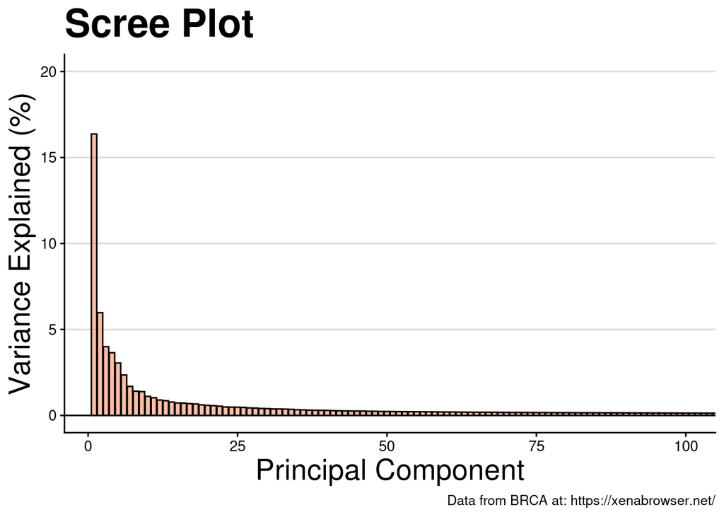

```r
scree_plot <- pca_fit |>
  tidy("pcs") |>
  mutate(percent = percent * 100) |>
  ggplot(aes(x = PC,
             y = percent)) +
  geom_hline(yintercept = 0) +
  geom_col(colour = "black",
           alpha = 0.5,
           fill = "coral") +
  theme_half_open(12) +
  background_grid() +
  theme(panel.grid.minor.x = element_blank(),
        panel.grid.major.x = element_blank(),
        plot.title = element_text(size=27),
        axis.title.x = element_text(size = 20),
        axis.title.y = element_text(size = 20)) +
  labs(title = "Scree Plot",
       x = "Principal Component",
       y = "Variance Explained (%)",
       caption = "Data from BRCA at: https://xenabrowser.net/") +
  coord_cartesian(xlim = c(1, 100), ylim = c(0, 20))


scree_plot
```

When looking at the Scree plot, we can see that the first two PCs only explain about 22% of the variance, meaning that not a lot of the information is retained in the PCA plot.

## Plotting the rotation matrix

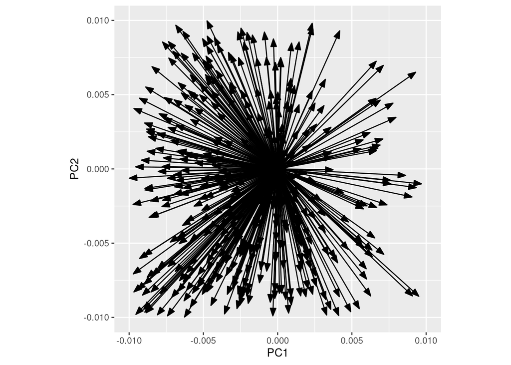

```r
arrow_style <- arrow(angle = 20,
                     ends = "first",
                     type = "closed",
                     length = grid::unit(8, "pt"))

pca_fit |>
  tidy(matrix = "rotation") |>
  pivot_wider(names_from = "PC",
              names_prefix = "PC",
              values_from = "value") |>
  ggplot(aes(PC1, PC2)) +
  geom_segment(xend = 0,
               yend = 0,
               arrow = arrow_style) +
  xlim(-0.01, 0.01) + ylim(-0.01, 0.01) +
  coord_fixed()
```

### Grouping and nesting cancer stage and performing PCA on each group

This testing is preformed to see if there is any gene expression clustering within the cancer stages

Nesting data by cancer stage

```r
nested_data <- data_pivot |>
  group_by(cancer_stage) |>
  nest()
```

Performing PCA on each group within the nested data

```r
pca_results <- nested_data |>
  mutate(
    pca = map(data, ~ {
      .x |>
        select(starts_with("ENSG")) |>
        select(where(~ any(. != 0))) |>
        scale() |>
        prcomp()
    })
  ) |>
  mutate(
    pca_aug = map2(pca, data, ~augment(.x, data = .y))
  )
```

Selecting the pca data and unnesting

```r
pca_plot_data <- pca_results |>
  select(cancer_stage, pca_aug)  |>
  unnest(pca_aug)
```

Plotting each of the stage PCAs

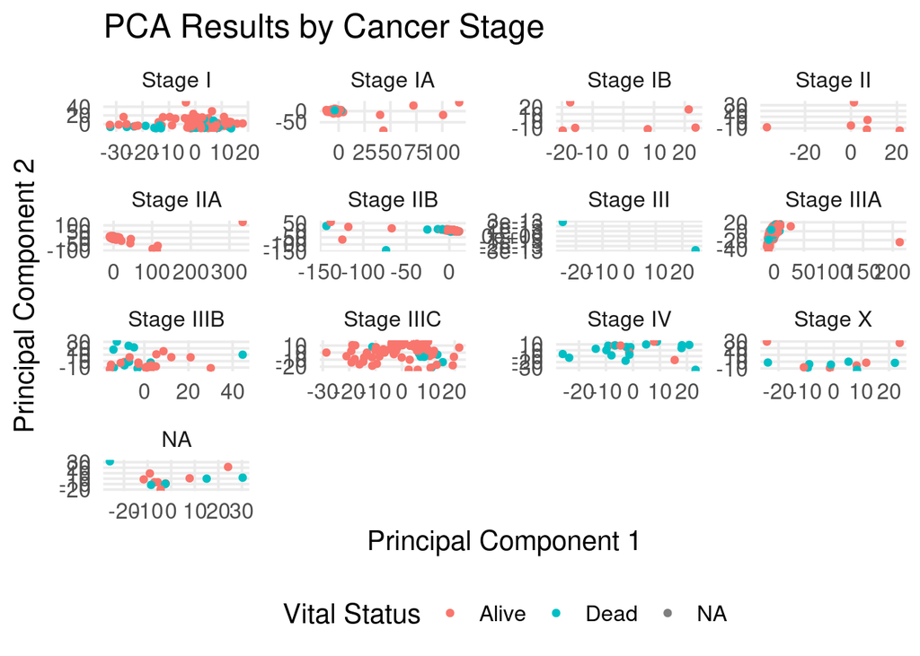

```r
ggplot(pca_plot_data, aes(x = .fittedPC1, y = .fittedPC2, color = vital_status)) +
    geom_point(size = 1.5) +
    facet_wrap(~ cancer_stage, scales = "free") +
    theme_minimal(base_size = 15) +
    labs(
      title = "PCA Results by Cancer Stage",
      x = "Principal Component 1",
      y = "Principal Component 2",
      color = "Vital Status"
    ) +
    theme(
      legend.position = "bottom",
      panel.grid.minor = element_blank()
    )
```

When looking at these plots it is not evedint that any of the stages contain clusters. Though we want to look further into the Stage IIIB

Looking at just one PCA

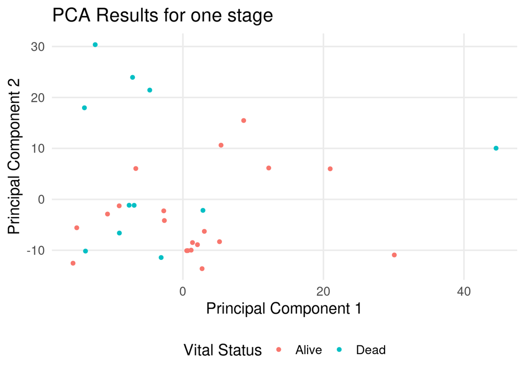

```r
pca_plot_data |>
  filter(cancer_stage == "Stage IIIB")  |>
  ggplot(aes(x = .fittedPC1, y = .fittedPC2, color = vital_status)) +
    geom_point(size = 1.5) +
    theme_minimal(base_size = 15) +
    labs(
      title = "PCA Results for one stage",
      x = "Principal Component 1",
      y = "Principal Component 2",
      color = "Vital Status"
    ) +
    theme(
      legend.position = "bottom",
      panel.grid.minor = element_blank()
    )
```

There are not any specific clustering when looking at the Stage IIIB PCA with vital status as markers.

## Linear modelling

### Plot of years at diagnosis vs age at diagnosis, by cancer stage.

The plots highlight the correlation between the age of patient diagnosed and when the patient dies and by which diagnosis (stage).

### Filter and factorize the data

```r
data_factored <- data |>
  filter(
    !is.na(age_at_diagnosis_years) &
    !is.na(years_from_diagnosis_to_death)
  ) |>
  mutate(
    cancer_stage = factor(
      cancer_stage,
      levels = c(
        "Stage I",
        "Stage IA",
        "Stage IB",
        "Stage II",
        "Stage IIA",
        "Stage IIB",
        "Stage III",
        "Stage IIIA",
        "Stage IIIB",
        "Stage IIIC",
        "Stage IV"
      )
    )
  )
```

### Calculate correlations for each cancer stage

```r
correlations <- data_factored |>
  group_by(cancer_stage) |>
  summarize(
    correlation = cor(age_at_diagnosis_years,
                      years_from_diagnosis_to_death,
                      use = "complete.obs"),
    .groups = "drop"
  )
```

### Creating the plot

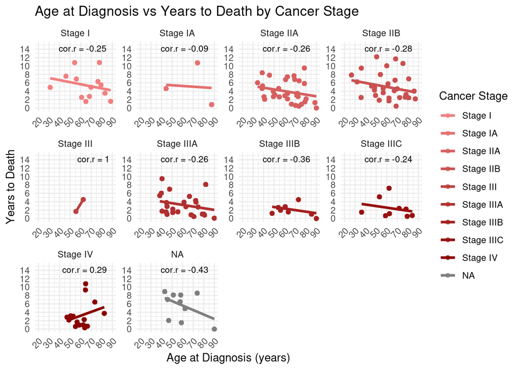

```r
data_factored |>
  ggplot(aes(x = age_at_diagnosis_years, y = years_from_diagnosis_to_death, color = cancer_stage)) +
  geom_point(alpha = 0.7) +
  geom_smooth(method = "lm", se = FALSE, size = 1.2) +
  scale_color_manual(
    values = colorRampPalette(c("lightcoral", "darkred"))(9)
  ) +
  facet_wrap(~ cancer_stage, scales = "free") +
  geom_text(
    data = correlations,
    aes(x = Inf, y = Inf, label = paste("cor.r =", round(correlation, 2))),
    inherit.aes = FALSE,
    hjust = 1.2, vjust = 1.5, size = 3
  ) +
  labs(
    title = "Age at Diagnosis vs Years to Death by Cancer Stage",
    x = "Age at Diagnosis (years)",
    y = "Years to Death",
    color = "Cancer Stage"
  ) +
  scale_x_continuous(
    limits = c(20, 90),
    breaks = seq(20, 90, by = 10)
  ) +
  scale_y_continuous(
    limits = c(0, 15),
    breaks = seq(0, 15, by = 2)
  ) +
  theme_minimal() +
  theme(
    axis.text.x = element_text(angle = 45, hjust = 1)
  )
```

Separate code for calculation of the correlations and mean age of diagnosis and mean days to death:

```r
summary_stats_by_stage <- data |>
  filter(
    !is.na(age_at_diagnosis_years) &
    !is.na(years_from_diagnosis_to_death)
  ) |>
  group_by(cancer_stage) |>
  summarize(
    mean_age = mean(age_at_diagnosis_years, na.rm = TRUE),
    mean_years_to_death = mean(years_from_diagnosis_to_death, na.rm = TRUE),
    correlation = cor(age_at_diagnosis_years,
                      years_from_diagnosis_to_death,
                      use = "complete.obs"),
    .groups = "drop"
  )

summary_stats_by_stage
```

```
# A tibble: 11 × 4
   cancer_stage mean_age mean_years_to_death correlation
   <chr>           <dbl>               <dbl>       <dbl>
 1 Stage I          67.4                5.28     -0.251
 2 Stage IA         62.5                5.20     -0.0906
 3 Stage IIA        62.6                4.18     -0.265
 4 Stage IIB        58.9                5.35     -0.279
 5 Stage III        59.0                3.10      1
 6 Stage IIIA       58.8                3.30     -0.260
 7 Stage IIIB       68.0                2.08     -0.365
 8 Stage IIIC       65.2                2.40     -0.242
 9 Stage IV         59.6                3.15      0.290
10 Stage X          59.9                4.30     -0.531
11 <NA>             53.5               10.8      -0.252
```

### Plot of years at diagnosis vs age at diagnosis.

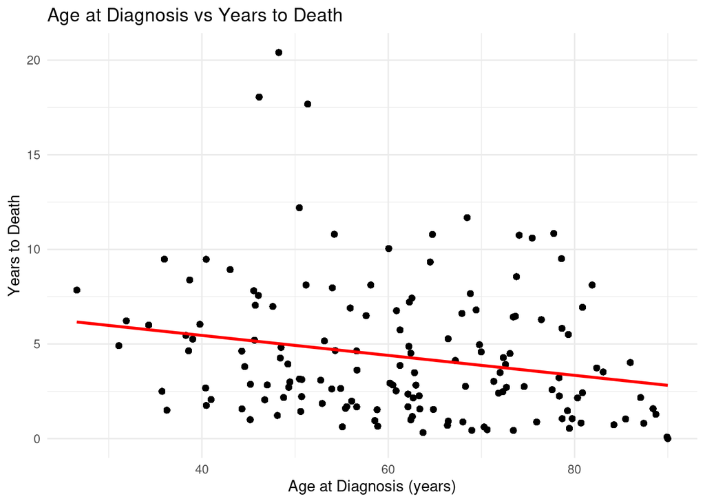

```r
ggplot(data, aes(x = age_at_diagnosis_years,
                 y = years_from_diagnosis_to_death)) +
  geom_point(alpha = 0.7) +
  geom_smooth(method = "lm", color = "red") +
  labs(
    title = "Age at Diagnosis vs Years to Death",
    x = "Age at Diagnosis (years)",
    y = "Years to Death"
  ) +
  theme_minimal()
```

Separate code for calculation of the correlation and mean age of diagnosis and mean years to death:

```r
summary_stats <- data |>
  filter(
    !is.na(age_at_diagnosis_years) &
    !is.na(years_from_diagnosis_to_death)
  ) |>
  summarize(
    mean_age = mean(age_at_diagnosis_years,
                    na.rm = TRUE),
    mean_years_to_death = mean(years_from_diagnosis_to_death,
                               na.rm = TRUE),
    correlation = cor(age_at_diagnosis_years,
                      years_from_diagnosis_to_death,
                      use = "complete.obs")
  )

summary_stats
```

```
# A tibble: 1 × 3
  mean_age mean_years_to_death correlation
     <dbl>               <dbl>       <dbl>
1     61.5                4.32      -0.241
```

### Setup of linear model to describe years from diagnosis to death

```r
filtered_data <- data |>
  filter(
    !is.na(cancer_stage),
    treatment != "not reported"
  )
```

```r
lm_model <- lm(
  years_from_diagnosis_to_death ~
    cancer_stage +
    age_at_diagnosis_years +
    treatment +
    prior_malignancy,
  data = filtered_data
)

summary(lm_model)
```

```
Call:
lm(formula = years_from_diagnosis_to_death ~ cancer_stage + age_at_diagnosis_years +
    treatment + prior_malignancy, data = filtered_data)

Residuals:
    Min      1Q  Median      3Q     Max
-4.2078 -2.4280 -0.8517  1.5551 13.3107

Coefficients:
                         Estimate Std. Error  t value Pr(>|t|)
(Intercept)             9.3665580  0.0448841  208.683  < 2e-16 ***
cancer_stageStage IA    2.4121503  0.0613182   39.338  < 2e-16 ***
cancer_stageStage IIA  -1.8020349  0.0341624  -52.749  < 2e-16 ***
cancer_stageStage IIB  -0.4864214  0.0345614  -14.074  < 2e-16 ***
cancer_stageStage III  -2.5981415  0.0590673  -43.986  < 2e-16 ***
cancer_stageStage IIIA -2.5032371  0.0352006  -71.113  < 2e-16 ***
cancer_stageStage IIIB -3.7541315  0.0445864  -84.199  < 2e-16 ***
cancer_stageStage IIIC -2.4900762  0.0403693  -61.682  < 2e-16 ***
cancer_stageStage IV   -2.0211424  0.0375224  -53.865  < 2e-16 ***
cancer_stageStage X    -1.0694465  0.0414023  -25.831  < 2e-16 ***
age_at_diagnosis_years -0.0613965  0.0004729 -129.837  < 2e-16 ***
treatmentyes           -0.0463754  0.0151169   -3.068  0.00216 **
prior_malignancyyes    -2.0869106  0.0272447  -76.599  < 2e-16 ***
---
Signif. codes:  0 '***' 0.001 '**' 0.01 '*' 0.05 '.' 0.1 ' ' 1

Residual standard error: 3.141 on 231987 degrees of freedom
  (1930000 observations deleted due to missingness)
Multiple R-squared:  0.1782,    Adjusted R-squared:  0.1782
F-statistic:  4192 on 12 and 231987 DF,  p-value: < 2.2e-16
```

### Filter out “not reported” and NA values in `cancer_stage`, and ensure no missing values in key variables

```r
filtered_data <- data |>
  filter(
    !is.na(cancer_stage),
    treatment != "not reported",
    !is.na(age_at_diagnosis_years),
    !is.na(years_from_diagnosis_to_death)
  )

filtered_data <- filtered_data |>
  mutate(predicted_years_to_death = predict(lm_model))
```

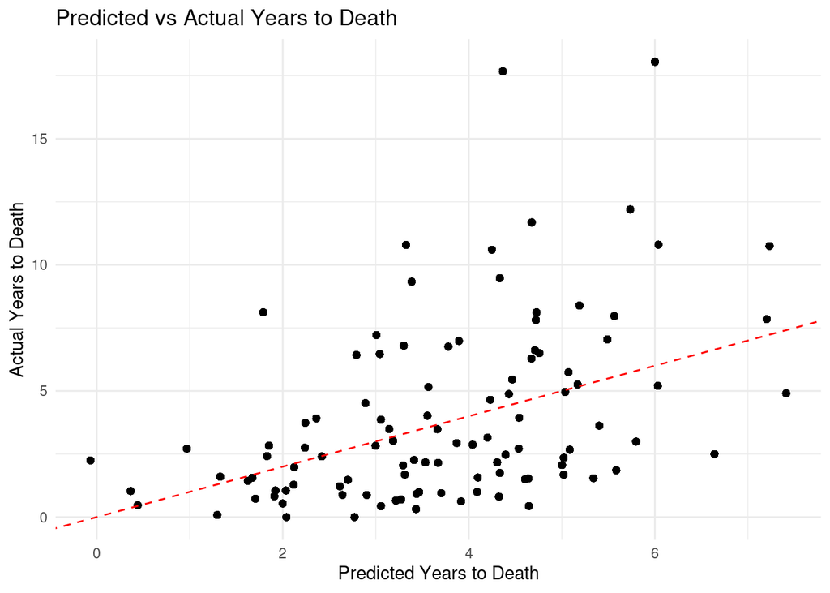

```r
ggplot(filtered_data, aes(x = predicted_years_to_death,
                          y = years_from_diagnosis_to_death)) +
  geom_point(alpha = 0.6) +
  geom_abline(slope = 1,
              intercept = 0,
              color = "red",
              linetype = "dashed") +
  labs(
    title = "Predicted vs Actual Years to Death",
    x = "Predicted Years to Death",
    y = "Actual Years to Death"
  ) +
  theme_minimal()
```

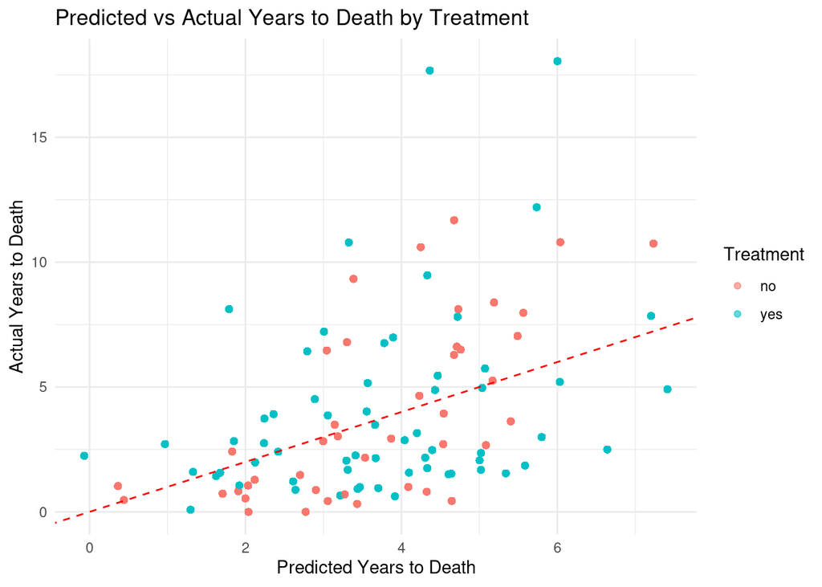

```r
filtered_data |>
  ggplot(aes(x = predicted_years_to_death,
             y = years_from_diagnosis_to_death,
             color = treatment)) +
  geom_point(alpha = 0.6) +
  geom_abline(slope = 1,
              intercept = 0,
              color = "red",
              linetype = "dashed") +
  labs(
    title = "Predicted vs Actual Years to Death by Treatment",
    x = "Predicted Years to Death",
    y = "Actual Years to Death",
    color = "Treatment"
  )  +
  theme_minimal()
```

### Plot actual vs. predicted, faceted by treatment and prior malignancy

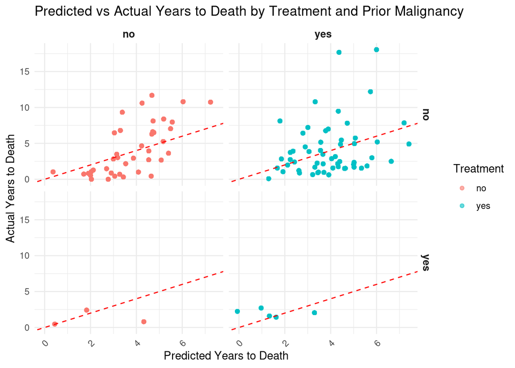

```r
filtered_data |>
  ggplot(aes(x = predicted_years_to_death,
             y = years_from_diagnosis_to_death,
             color = treatment)) +
  geom_point(alpha = 0.6) +
  geom_abline(slope = 1, intercept = 0, color = "red", linetype = "dashed") +
  labs(
    title = "Predicted vs Actual Years to Death by Treatment and Prior Malignancy",
    x = "Predicted Years to Death",
    y = "Actual Years to Death",
    color = "Treatment"
  ) +
  facet_grid(prior_malignancy ~ treatment) +
  theme_minimal() +
  theme(
    strip.text = element_text(size = 10, face = "bold"),
    axis.text.x = element_text(angle = 45, hjust = 1)
  )
```